# Modeling the Epidemic Outbreak and Dynamics of COVID-19 in Croatia

## (Second Edition)

ArXiV submission date: *4 May 2020*  
Presentation date: *23 September 2020*

### Authors

Ante Lojic Kapetanovic (alojic00@fesb.hr)  
Dragan Poljak (dpoljak@fesb.hr)

### Affiliation

Department of Electronics and Computer Engineering @FESB @University of Split

## Content

- Abstract
- Introduction
- Initial outbreak modeling
  - Trend visualization
  - Growth modeling
    - Exponential growth
    - Sigmoidal griwth
- Dynamics modeling
  - Modified SEIR model
  - Further updates
  - Interesting read
- Conclusion
- Supplementary material

## Abstract

The paper deals with a modeling of the ongoing epidemic caused by Coronavirus disease 2019 (COVID-19) on the closed territory of the Republic of Croatia. Using the official public information on the number of confirmed infected, recovered and deceased individuals, the modified SEIR compartmental model is developed to describe the underlying dynamics of the epidemic. Fitted modified SEIR model provides the prediction of the disease progression in the near future, considering strict control interventions by means of social distancing and quarantine for infected and at-risk individuals introduced at the beginning of COVID-19 spread on February, 25th by Croatian Ministry of Health. Assuming the accuracy of provided data and satisfactory representativeness of the model used, the basic reproduction number is derived. Obtained results portray potential positive developments and justify the stringent precautionary measures introduced by the Ministry of Health.

Paper preprint available at https://arxiv.org/abs/2005.01434.

## Introduction

<sup>1</sup>S. Zhao and H. Chen, “Modeling the epidemic dynamics and control of COVID-19 outbreak in China,” Quantitative Biology, vol. 8, no. 1, pp. 11–19, Mar. 2020.  
<sup>2</sup>W. O. Kermack and A. G. McKendrick, “Contributions to the mathematical theory of epidemics — I”, Bulletin of Mathematical Biology, vol. 53, no. 1-2, pp. 33–55, Mar. 1991.

## Initial outbreak modeling

### Trend in data

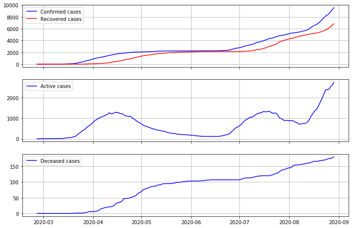

```python
plot_dataframe(df)
```

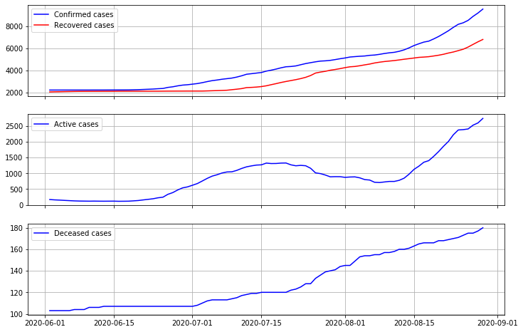

```python
plot_dataframe(df_2)
```

### Growth modeling

#### Exponential growth

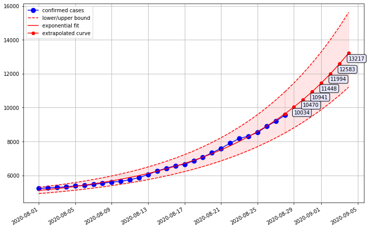

```python
eff_date = dt.datetime(2020, 8, 1)

growth_simulation(
    function='exponential',
    eff_date=eff_date,
    confirmed_cases=df_2[df_2.date > eff_date].confirmed_cases.values,
    n_days=7,
    plot_confidence_intervals=True
)
```

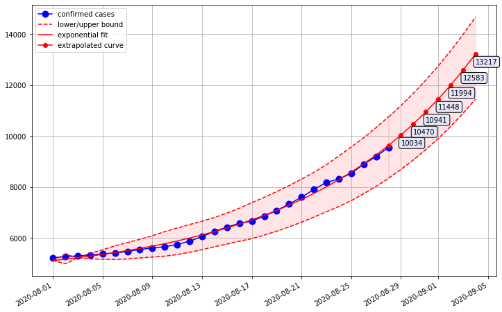

```python
eff_date = dt.datetime(2020, 8, 1)

growth_simulation(
    function='exponential',
    eff_date=eff_date,
    confirmed_cases=df_2[df_2.date > eff_date].confirmed_cases.values,
    n_days=7,
    plot_confidence_intervals=True,
    sensitivity=0.98, ci_level=95
)
```

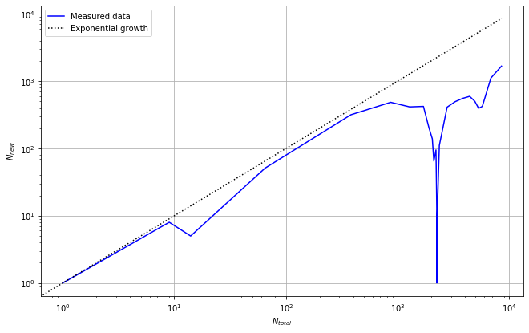

```python
averaged_new_cases_v_total_cases(confirmed_cases)
```

#### Sigmoidal growth

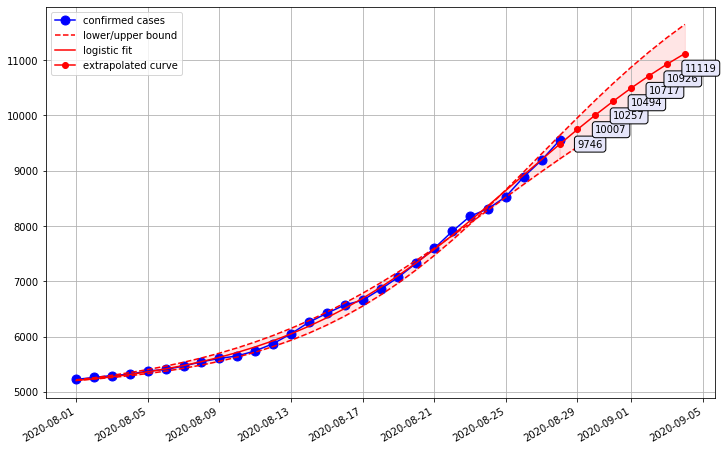

```python
eff_date = dt.datetime(2020, 8, 1)

growth_simulation(
    function='logistic',
    eff_date=eff_date,
    confirmed_cases=df_2[df_2.date > eff_date].confirmed_cases.values,
    n_days=7,
    plot_confidence_intervals=True
)
```

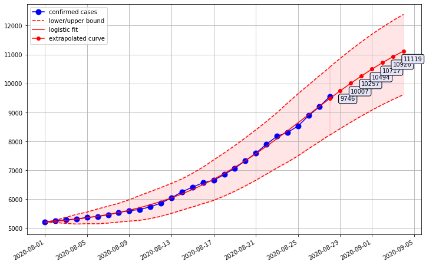

```python
eff_date = dt.datetime(2020, 8, 1)

growth_simulation(
    function='logistic',
    eff_date=eff_date,
    confirmed_cases=df_2[df_2.date > eff_date].confirmed_cases.values,
    n_days=7,
    plot_confidence_intervals=True,
    sensitivity=0.98, ci_level=95
)
```

## Dynamics modeling

### Modified SEIR model

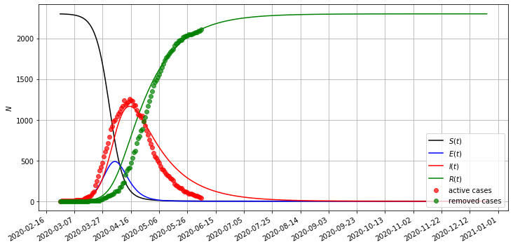

```python
S0 = 2300
E0 = 1
I0 = active_cases_1[0]
R0 = removed_cases_1[0]

R_0, loss = SEIR_simulation(
    active_cases=active_cases_1,
    removed_cases=removed_cases_1,
    initial_conditions=(S0, E0, I0, R0),
    split_ratio=1.,
    epidemics_start_date=start_date_1,
)
```

In epidemiology, the basic reproduction number, or basic reproductive number, denoted $R_0$ and pronounced R nought or R zero, of an infection can be thought of as the expected number of cases directly generated by one case in a population where all individuals are susceptible to infection.

```python
R_0
```

```
1.181204728707816
```

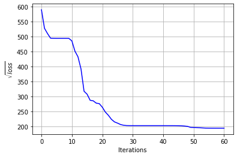

```python
plt.plot(np.sqrt(loss), 'b-')
plt.xlabel('Iterations')
plt.ylabel(r'$\sqrt{loss}$')
plt.grid()
plt.show()
```

### Further updates

### Interesting read

## Conclusion

## Supplementary material

Data source: https://www.koronavirus.hr/

Code repository: https://github.com/antelk/covid-19

For all questions: alojic00@fesb.hr